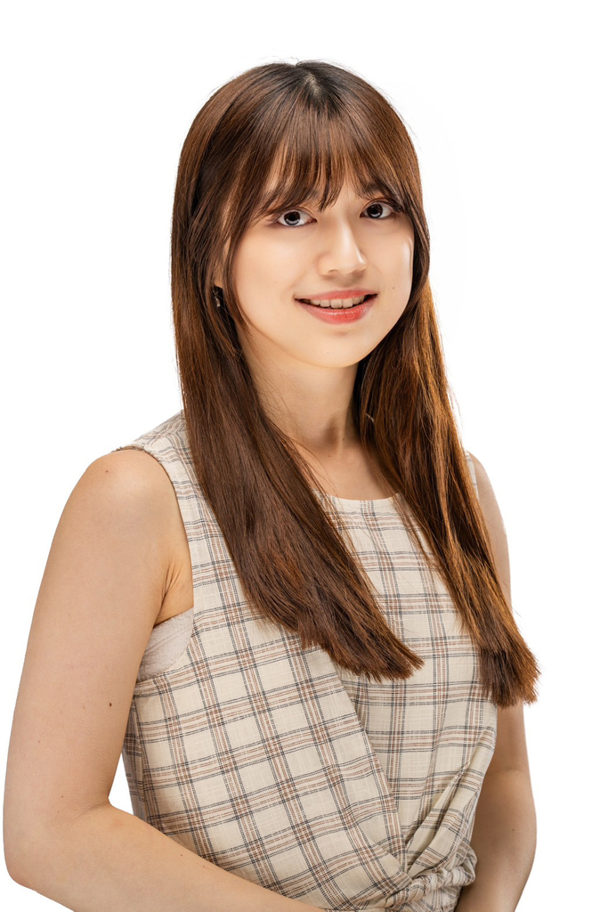

# Emilie Cheng

## Bio

Emilie Cheng is a second-year Master’s student in Epidemiology at [Johns Hopkins Bloomberg School of Public Health](https://publichealth.jhu.edu/). Her academic background began in Veterinary Medicine (DVM) at [National Taiwan University](https://www.ntu.edu.tw/english/), and she is now expanding her expertise into clinical trials, pharmacoepidemiology, and pharmacovigilance.

## Education

**Johns Hopkins Bloomberg School of Public Health** | Baltimore, MD

M.S. in Epidemiology | August 2024 - May 2026 (Expected)

**National Taiwan University** | Taipei, Taiwan

D.V.M. | August 2017 - May 2022

## Master’s Thesis

**Title: A Mixed-Methods Analysis of Factors Associated with Patient and Provider Use of a Digital Health Intervention** *Advisors: Dr. Sheriza (Primary) & Dr. Ann (Research Track Director)*

My Master’s thesis research is tied to the Social Needs App for Oncology Patients (SNAP-ON) Phase II project. The study utilizes a mixed-methods approach, triangulating patient-reported quantitative data with provider-reported clinical workflow realities. By simultaneously capturing the experiences of both oncology patients and providers, this study providing valuable and actionable feedback to app developers.

## Experience

**Elanco Animal Health** | Global Pharmacovigilance Intern | May 2025 - August 2025

**Taiwan CDC** | Technician | Nov 2022 - Oct 2023

**National Taiwan University** | Undergrad Student Researcher| Aug 2020 - June 2021

**Academia Sinica, Taiwan** | Research Intern | July 2019 - Aug 2019

## Skills

R (Programming Language), SAS  
Excel, Power BI, SQL, Redcap  
Veterinary Medicine, Epidemiology, Statistics, Pharmacovigilance

## Interests and Hobbies

**Piano** | A lifelong amateur player  
**Baking** | I recently start raising my sourdough starter  
**Working out** | My goal is to maintain an every-other-day schedule